# Acumen LLC Data Exercise

Kunal Mishra

3/10/2018

### Introduction & Background Information

1. A large company, Company A, provides health insurance to its employees.
2. Every four years, Company A’s insurer, InsurAHealth, reviews the health status of the employees.
   - To do this, InsurAHealth calculates a health score between 0 and 6 for each employee on a quarterly basis
   - 0 denotes a very health person, and 6 denotes a very sick person
   - The health score is a proprietary tool used by InsurAHealth. The items that go into its formula are not public.
3. This past review cycle, InsurAHealth claimed that the employees at Company A have gotten sicker. The mean health score in Quarter 1 was 3.4, in Quarter 6 it was 3.5, and in Quarter 12, it was 3.9.

```r
library(DataExplorer)
library(data.table)

InsurAHealthData = data.table::fread(input="InsurAHealthData.csv", header=TRUE)

# Modifying Salary to be a continuous numeric variable
InsurAHealthData[, ] #Check out gsub package
```

```
##        Observation Number Quarter Employee Id Sex (Male=1) Race Age
##     1:                  1       1           1            0    3  27
##     2:                  2       2           1            0    3  28
##     3:                  3       3           1            0    3  28
##     4:                  4       4           1            0    3  28
##     5:                  5       5           1            0    3  29
##    ---
## 19099:              19099       8        2000           NA    1  28
## 19100:              19100       9        2000           NA    1  28
## 19101:              19101      10        2000           NA    1  28
## 19102:              19102      11        2000           NA    1  28
## 19103:              19103      12        2000           NA    1  29
##        Hospital Visit This Quarter (1=Yes)  Salary Health Score
##     1:                                   0 $36,907          3.7
##     2:                                   0 $37,907          5.0
##     3:                                   0 $38,907          4.0
##     4:                                   0 $39,907          2.3
##     5:                                   0 $40,907          2.1
##    ---
## 19099:                                   0 $59,905         10.0
## 19100:                                   1 $60,905         10.0
## 19101:                                   0 $61,905         10.0
## 19102:                                   0 $62,905         10.0
## 19103:                                   0 $63,905         10.0
```

```r
InsurAHealthData
```

```
##        Observation Number Quarter Employee Id Sex (Male=1) Race Age
##     1:                  1       1           1            0    3  27
##     2:                  2       2           1            0    3  28
##     3:                  3       3           1            0    3  28
##     4:                  4       4           1            0    3  28
##     5:                  5       5           1            0    3  29
##    ---
## 19099:              19099       8        2000           NA    1  28
## 19100:              19100       9        2000           NA    1  28
## 19101:              19101      10        2000           NA    1  28
## 19102:              19102      11        2000           NA    1  28
## 19103:              19103      12        2000           NA    1  29
##        Hospital Visit This Quarter (1=Yes)  Salary Health Score
##     1:                                   0 $36,907          3.7
##     2:                                   0 $37,907          5.0
##     3:                                   0 $38,907          4.0
##     4:                                   0 $39,907          2.3
##     5:                                   0 $40,907          2.1
##    ---
## 19099:                                   0 $59,905         10.0
## 19100:                                   1 $60,905         10.0
## 19101:                                   0 $61,905         10.0
## 19102:                                   0 $62,905         10.0
## 19103:                                   0 $63,905         10.0
```

##### Initial Observations

The initial heads and tails of the data indicate that each row is an employee’s data for a given quarter, and that the data is sorted by Employee ID, then Quarter, so that all of a unique employee’s data is consecutive. We also immediately see that there is a variety of demographic information, including Race, Age, and Sex, all of which is categorical (age could also be considered continuous but it is truncated to years). The only two continuous variables we have are then health score and salary. Another thing I can immediately see is missing values (denoted NA) and health scores that don’t correspond with what InsurAHealth claims, with a value of 10.0 exceeding the maximum score of 6.0.

In addition, though the salary column is meant to be a continuous numeric column, it comes in character type due to the ‘$’ and ‘,’ symbols within the numbers. This also makes any standard type casting a bit more difficult, so that will need to be corrected. Finally, column names with spaces in them will make my life just a bit more difficult in this analysis, so that will need to be changed as well.

Let’s make those corrections

```r
colnames(InsurAHealthData) = c("Observation_Number", "Quarter", "Employee_ID", "Sex_(Male=1)", "Race", "Age", "Hospital_Visit_This_Quarter_(1=Yes)", "Salary", "Health_Score")

salaryColumn = InsurAHealthData[,Salary]
str(salaryColumn)
```

```
##  chr [1:19103] "$36,907" "$37,907" "$38,907" "$39,907" "$40,907" ...
```

```r
salaryColumn = gsub("$", "", salaryColumn, fixed=TRUE)
str(salaryColumn)
```

```
##  chr [1:19103] "36,907" "37,907" "38,907" "39,907" "40,907" "41,907" ...
```

```r
salaryColumn = gsub(",", "", salaryColumn, fixed=TRUE)
str(salaryColumn)
```

```
##  chr [1:19103] "36907" "37907" "38907" "39907" "40907" "41907" "42907" ...
```

```r
InsurAHealthData$Salary = as.numeric(salaryColumn)
```

### Question 1 - Understanding the Data

##### a) Are all the values in the data reasonable? Are there missing values?

##### b) What are the characteristics of employees at Company A? Do these demographics change over time?

Let’s start by answering 1a. We noticed that there were missing and unreasonable values in our first look at the data, but let’s first try to figure out how big these issues are.

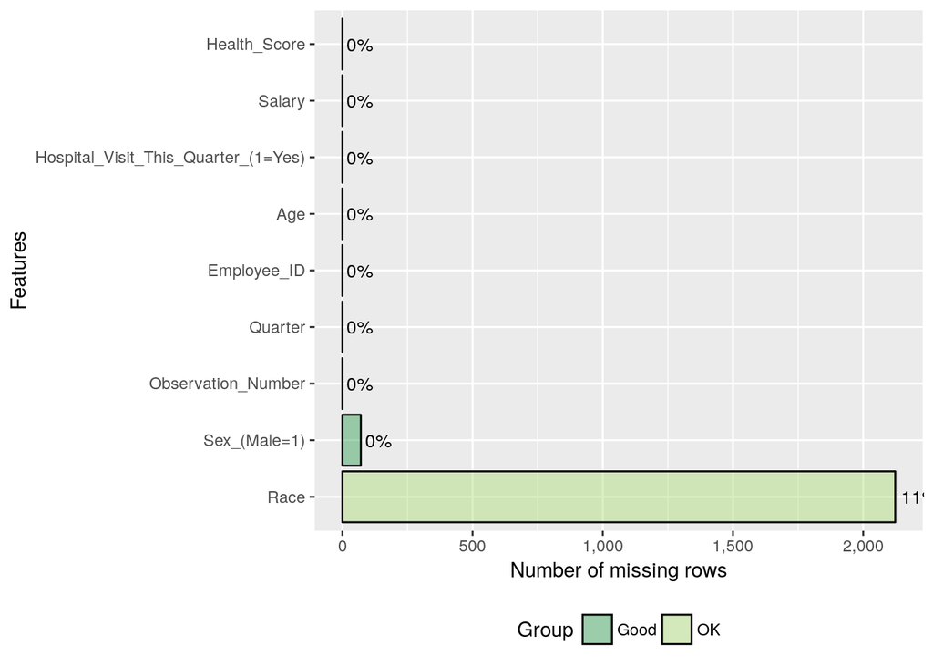

```r
DataExplorer::plot_missing(InsurAHealthData)
```

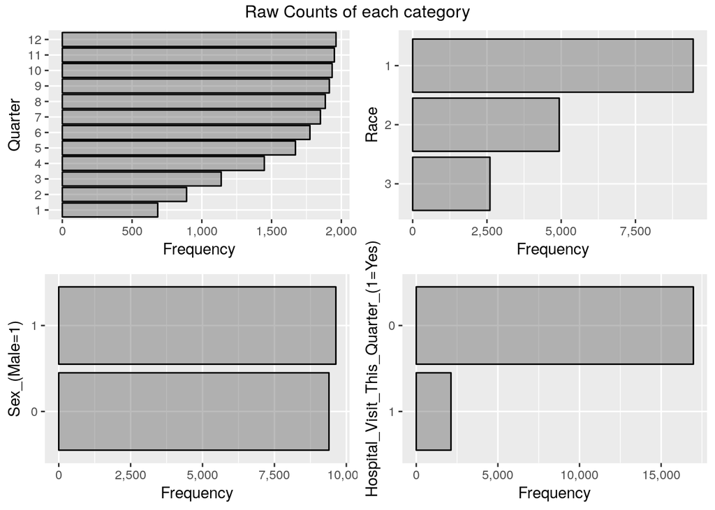

```r
# Looking for unexpected values - discrete data
DataExplorer::plot_bar(
    data = InsurAHealthData[, c("Quarter", "Race", "Sex_(Male=1)", "Hospital_Visit_This_Quarter_(1=Yes)"), with=FALSE][, lapply(.SD, as.factor)], title="Raw Counts of each category"
)
```

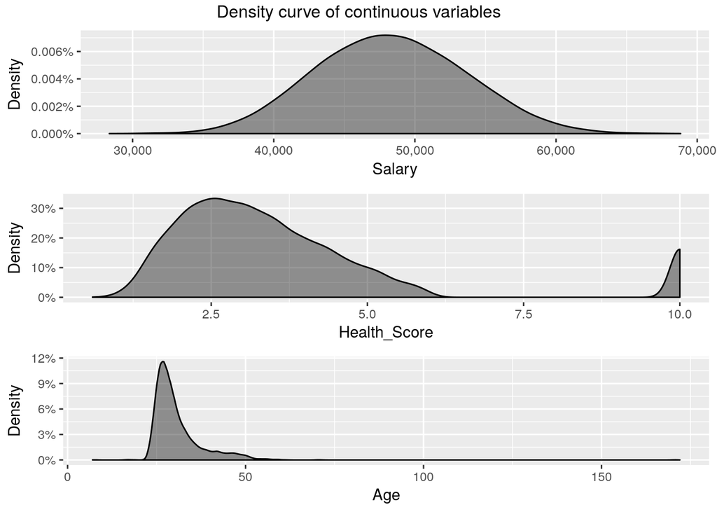

```r
#Looking for unexpected values - continuous data
DataExplorer::plot_density(
    data = InsurAHealthData[, c("Salary", "Health_Score", "Age"), with=FALSE][,lapply(.SD, as.numeric)],
    title = "Density curve of continuous variables"
)
```

```r
#Ensuring Employee_IDs have no more than 12 associated quarters (would be a signal that Employee_IDs are not unique to each employee)
```

[output not shown]

##### Further Observations

- Observations about Missing Data